# R for Beginners

# Data Visualization with R

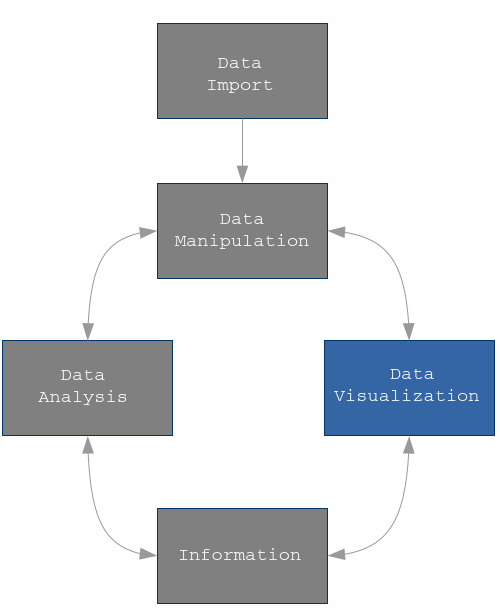

Visualizing data is crucial in today’s world. Without powerful visualizations, it is almost impossible to create and narrate stories on data. These stories help us build strategies and make intelligent business decisions.

`ggplot2` is a data visualization package which has become a synonym for data visualization in R.

```r
require(ggplot2)
```

Created by Hadley Wickham in 2005, `ggplot2` is an implementation of Leland Wilkinson’s Grammar of Graphics, a general scheme for data visualization which breaks up graphs into semantic independent components, such as scales and layers, that can be composed in many different ways. This makes `ggplot2` very powerful, because there are no limitations due to a set of pre-specified graphics, so it is possible to create new graphics that are precisely tailored for the problem in analysis.

## An overview of `ggplot2` grammar

Let us consider `people` dataset, included in `qdata` package. `people` dataset contains informations about weight, height, gender and geographical area of 300 italian people.

```r
require(qdata)
```

Suppose we want to visualize the relationship between weight and height of italian people according to the different geographical area, by using a **scatterplot**:

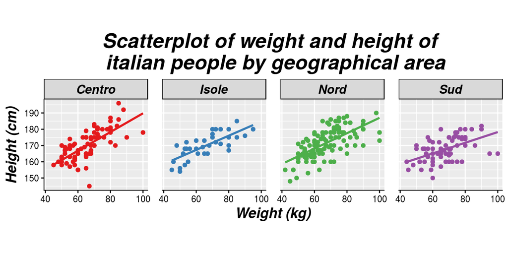

The previous plot is composed of building blocks that are added to the plot one after the other.

The complete scheme of the most important building blocks of `ggplot2` grammar is displayed in the following figure:

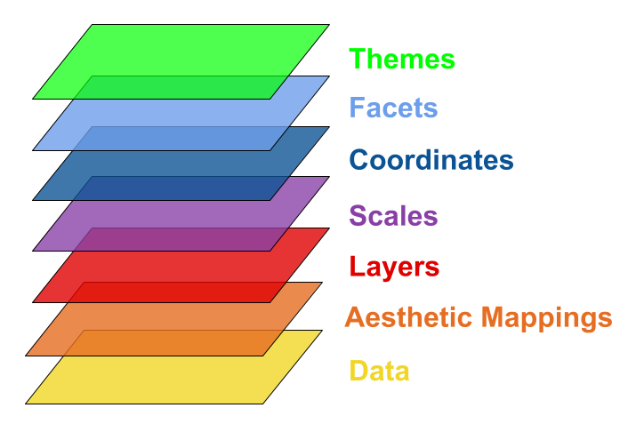

The scheme must be read from bottom to top. Starting from bottom, the first three building blocks ( **Data** , **Aestethic Mappings** and **Layers** ) are fundamental to build a simple plot, indeed they are called **“key”** building blocks. The remaining building blocks ( **Scales** , **Coordinates** , **Facets** and **Themes** ) allow us to build a complex plot and to customize it; their use and order is not compulsory.

Let us briefly describe the task of each element of the scheme and how it helps build the previous plot:

1. **Data** : the dataset that we want to visualize

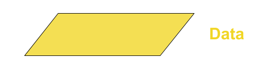

```r
# people dataset
data(people)
```

```r
head(people)
```

```
## # A tibble: 6 × 4
##   Gender   Area Weight Height
##   <fctr> <fctr>  <int>  <int>
## 1 Female  Isole     54    168
## 2 Female   Nord     61    171
## 3   Male    Sud     68    170
## 4 Female   Nord     52    164
## 5   Male   Nord     75    181
## 6   Male   Nord     77    178
```

2. **Aestethic Mappings** : describes how variables in the data are mapped to aestethic attributes that you can perceive

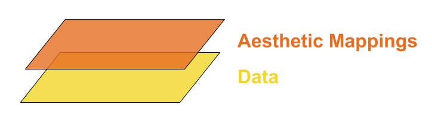

| Gender | Area | Weight | Height |
| --- | --- | --- | --- |
|  |  | x | y |

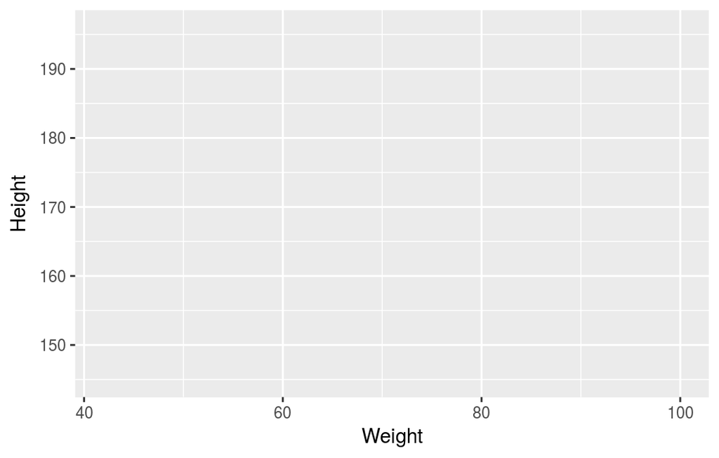

```r
ggplot(data = people, aes(x = Weight, y = Height))
```

3. **Layers** : are made up by geometric elements and statistical transformations. In details, geometric objects (`geom`s) represent what we actually see on the plot: points, lines, polygons, etc. Statistical transformations (`stat`s) summarise data in many useful ways. For example, binning and counting observations to create an histogram, or summarising a 2d relationship with a linear model.

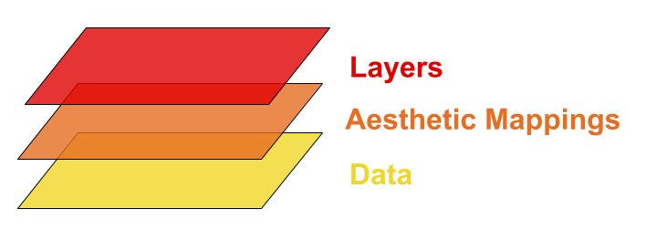

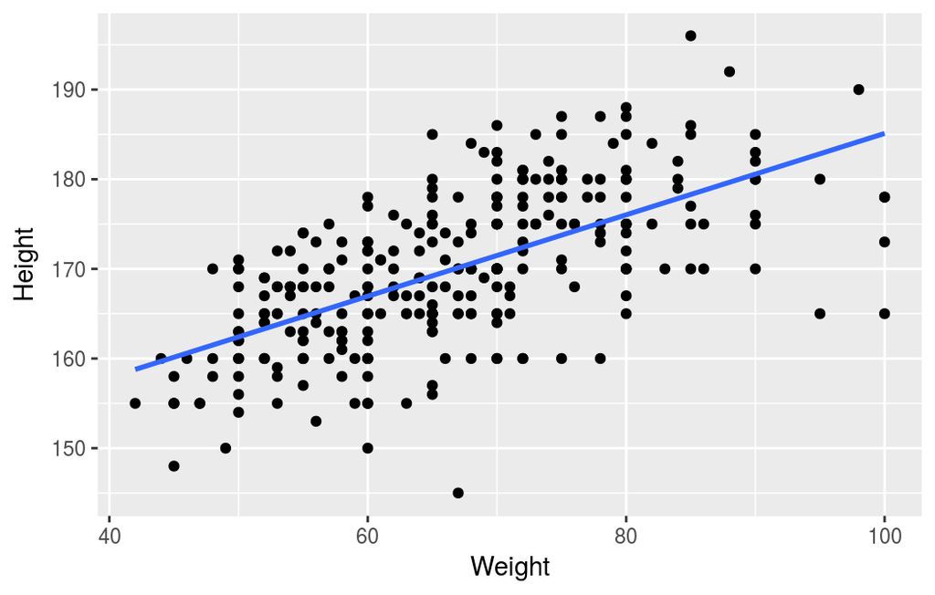

```r
# Scatterplot of the relationship between weight and height with regression line
ggplot(people, aes(x = Weight, y = Height)) +
  geom_point() + # layer 1 (draw points)
  stat_smooth(method = "lm", se = FALSE) # layer 2 (draw regression line)
```

4. **Scales** : map values in the data space to values in an aesthetic space, whether it be colour, or size or shape. Scales draw a legend on axes, which provide an inverse mapping to make it possible to read the original data values from the graph. Scales are closely related to aestethics mapped.

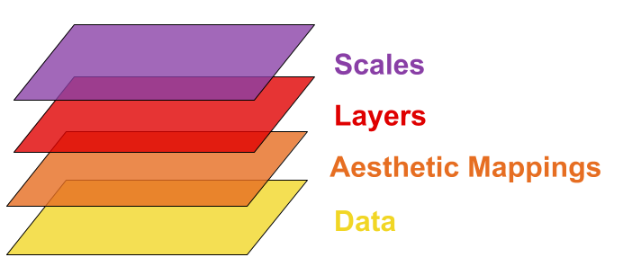

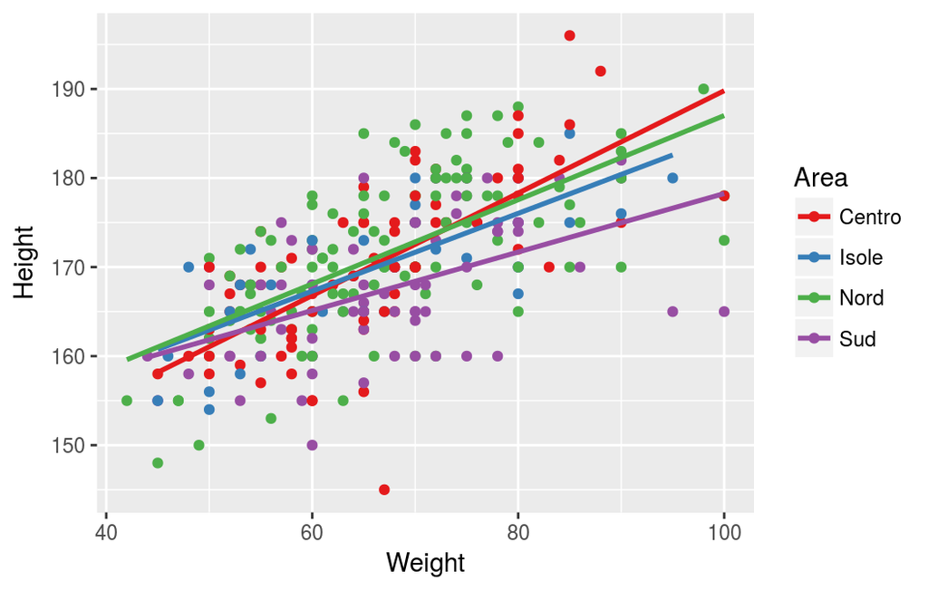

```r
# map Area to colour in aes() and change the default colours of colour scale
ggplot(people, aes(x = Weight, y = Height, colour = Area)) +
  geom_point() +
  geom_smooth(method = "lm", se = FALSE) +
  scale_colour_brewer(palette="Set1")
```

5. **Coordinates** : or coordinate system (coord) describe how data coordinates are mapped to the plane of the graphic. They also provides axes and gridlines to make it possible to read the graph. We normally use Cartesian coordinate system, but a number of others are available.

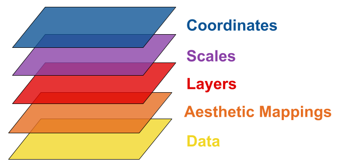

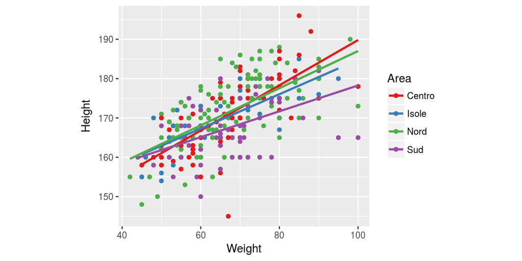

```r
# Generate a plot for each geographical area
ggplot(people, aes(x = Weight, y = Height, colour = Area)) +
  geom_point() +
  stat_smooth(method = "lm", se = FALSE) +
  scale_colour_brewer(palette="Set1") +
  coord_equal()
```

6. **Facets** : describes how to break up the data into subset and how to display those subsets as small multiples.

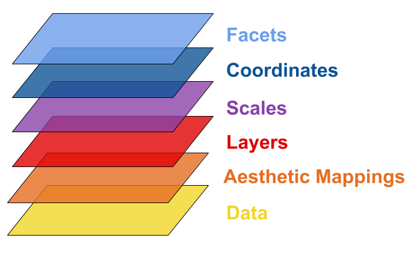

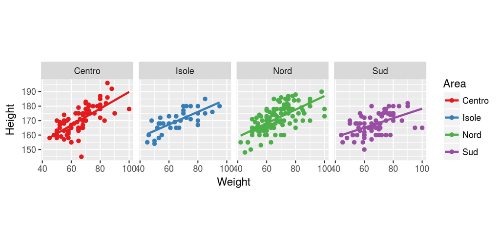

```r
# Generate a plot for each geographical area
ggplot(people, aes(x = Weight, y = Height, colour = Area)) +
  geom_point() +
  stat_smooth(method = "lm", se = FALSE) +
  scale_colour_brewer(palette="Set1") +
  coord_equal() +
  facet_grid(. ~ Area)
```

7. **Themes** : controls all non-data elements of the plot, like the font size, background colour, etc.

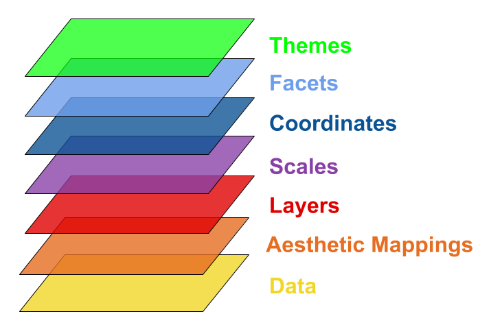

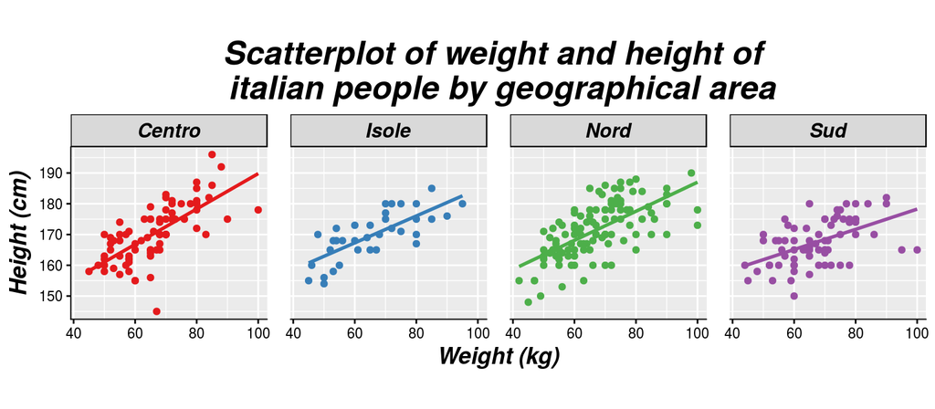

```r
# Customize the appearance of the plot
ggplot(people, aes(x = Weight, y = Height, colour = Area)) +
  geom_point() +
  stat_smooth(method = "lm", se = FALSE) +
  scale_colour_brewer(palette="Set1") +
  coord_equal() +
  facet_grid(. ~ Area) +
  ggtitle("Scatterplot of weight and height of \n italian people by geographical area") + # set title
    xlab("Weight (kg)") + # set x axis title
    ylab("Height (cm)") + # set y axis title
  theme(plot.background = element_blank(), # customize plot background
    axis.text = element_text(colour = "black"), # customize axes text
    axis.ticks = element_line(colour = "black"), # customize axes ticks
    axis.line.x = element_line(colour = "black"), # customize x axis line
    axis.line.y = element_line(colour = "black"), # customize y axis line
    axis.title = element_text(colour = "black", size = 14, face = "bold.italic"), # customize axes titles
    strip.background = element_rect(colour = "black"), # customize background of facet labels
    strip.text = element_text(colour = "black", face = "bold.italic", size = 12), # customize facet labels
    plot.title = element_text(colour = "black", size = 20, face = "bold.italic", hjust = 0.5), # customize plot title
    panel.spacing = unit(1, "lines"), # customize panels spacing
    legend.position = "none") # remove the legend
```

## Other plot types

The building block scheme previously seen can help us understanding how to build other plot types. We will focus on the first three building blocks of the scheme (data, aestethic mappings and layers).

- **Barplot**, which is used to show the count of each case of a categorial variable. Suppose we want to analyze the count of people by geographical area:

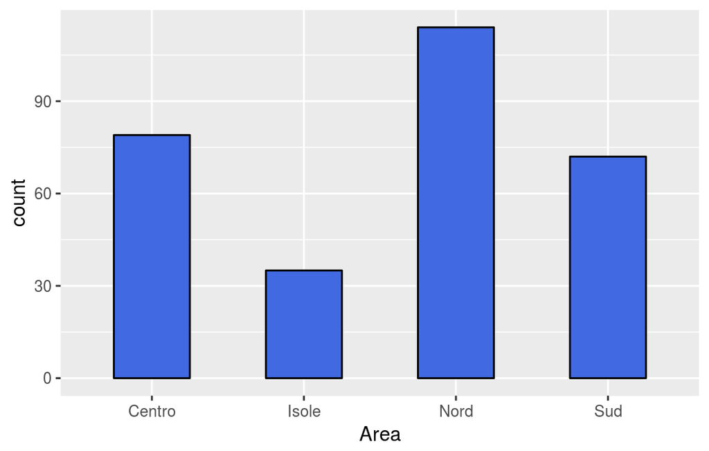

```r
# base plot: key building blocks (data, aes, layer)
ggplot(data = people, mapping = aes(x = Area)) +
  geom_bar(fill = "royalblue", colour = "black", width = 0.5)
```

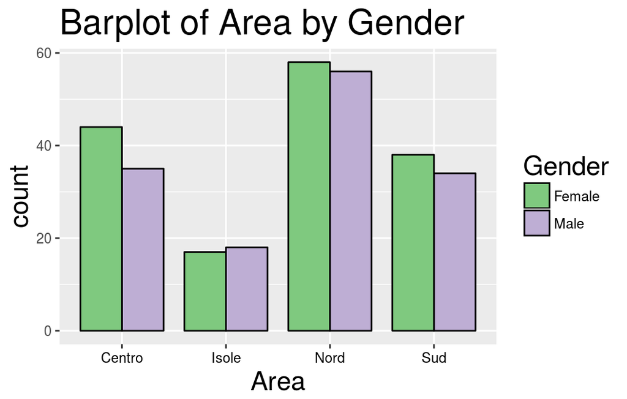

```r
# customized plot: key building blocks + scales + theme
ggplot(data = people, mapping = aes(x = Area, fill = Gender)) + # map Gender to fill scale
  geom_bar(position = "dodge", width = 0.8, colour="black") + # customize bar positions
       scale_fill_brewer(palette = "Accent") + # customize fill scale
       ggtitle("Barplot of Area by Gender") + # set title
       theme(axis.title.y = element_text(size = rel(1.5), angle = 90), # customize y axis title
             axis.title.x = element_text(size = rel(1.5)), # customize x axis title
             axis.text.x = element_text(colour="black"), # customize x axis text
             plot.title = element_text(size = rel(2)), # customize plot title
             legend.title = element_text(size = rel(1.5)))  # customize legend title
```

- **Histogram**, which is used to summarize a continuous variable into classes. Suppose we want to analyze the distribution of people weight:

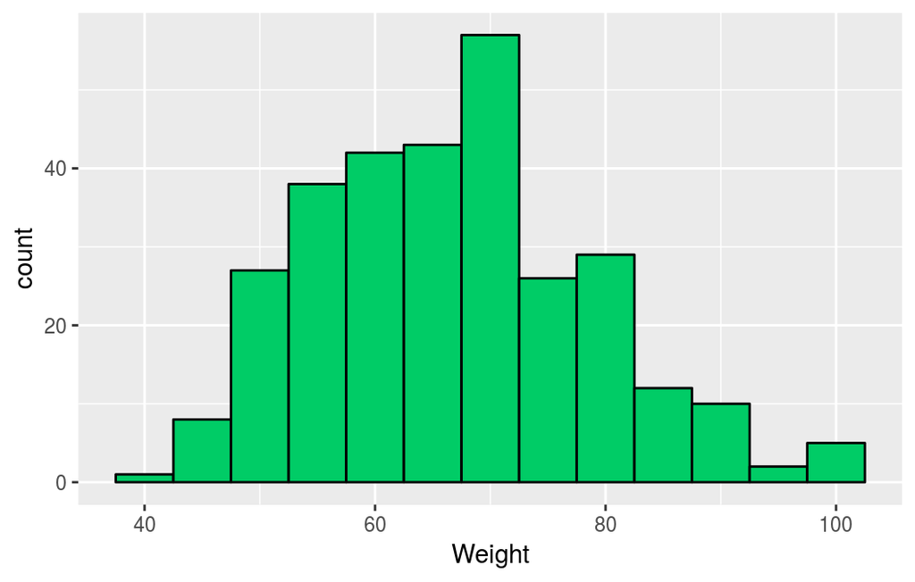

```r
# base plot: key building blocks (data, aes, layer)
ggplot(data=people, mapping=aes(x=Weight)) +
  geom_histogram(fill="#00cc66", colour= "#000000", binwidth=5)
```

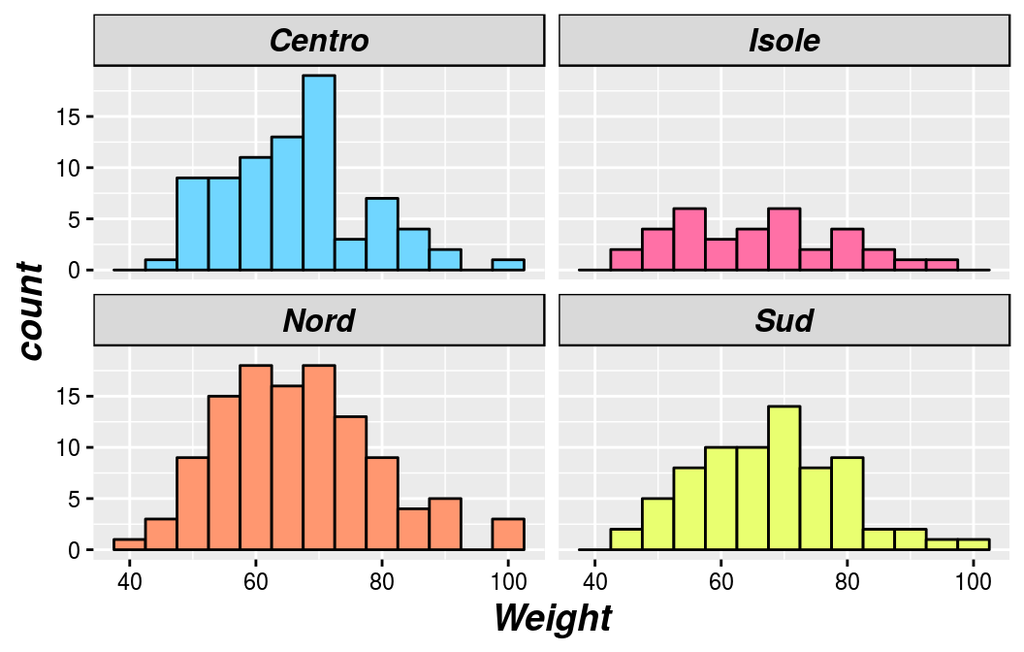

```r
# customized plot: key building blocks + scales + facet + theme
ggplot(data=people, mapping=aes(x=Weight)) +
  geom_histogram(mapping=aes(fill=Area), binwidth=5, colour="black") + # map Area to fill scale
  scale_fill_manual(values = c("#70D6FF", "#FF70A6", "#FF9770", "#E9FF70")) + # customize fill scale
  facet_wrap( ~ Area) + # generate a panel for each Area level
  theme(axis.text = element_text(colour = "black"), # customize axes text
    axis.ticks = element_line(colour = "black"), # customize axes
    axis.title = element_text(colour = "black", size = 14, face = "bold.italic"), # customize axes title
    strip.background = element_rect(colour = "black", fill=), # customize background of facet labels
    strip.text = element_text(colour = "black", face = "bold.italic", size = 12), # customize facet labels
    plot.title = element_text(colour = "black", size = 20, face = "bold.italic"), # customize plot title
    legend.position = "none") # remove legend
```

- **Boxplot**, which is used to draw a data distribution. Supposing you are interested in the differences of weight accordingly to geographical area:

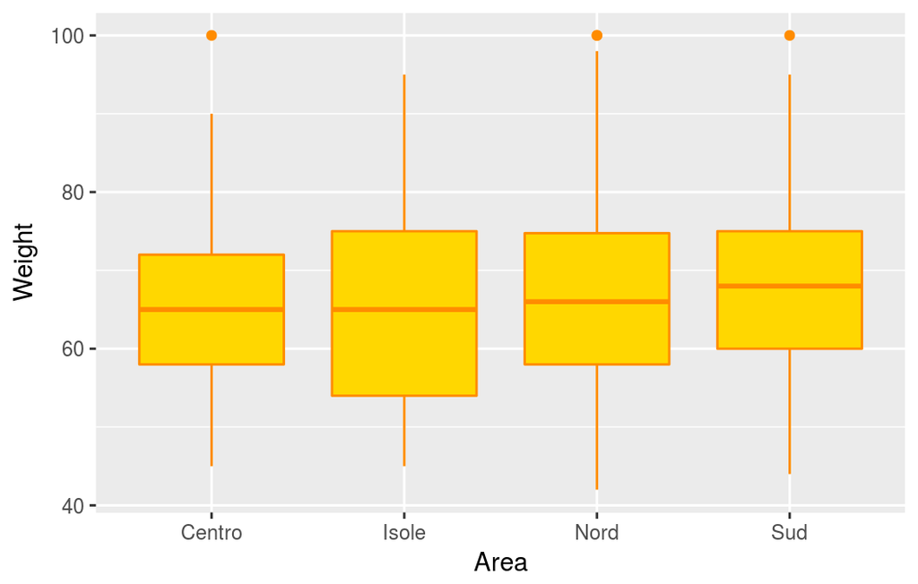

```r
# base plot: key building blocks (data, aes, layer)
ggplot(data=people, aes(x=Area, y=Weight)) +
  geom_boxplot(fill="gold", colour="darkorange")
```

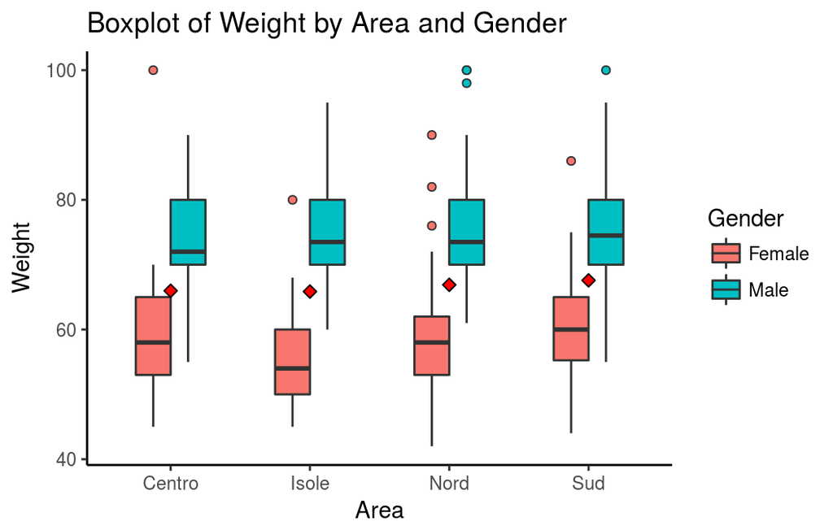

```r
# customized plot: key building blocks + scale + layer (stat) + theme
ggplot(data=people, aes(x=Area, y=Weight, fill=Gender)) + # map Gender to fill
  geom_boxplot(outlier.size = 1.5, outlier.shape = 21, width = .5) +
  stat_summary(fun.y = "mean", geom = "point", shape = 23, size = 2, fill = "red") + # compute and plot distributions means
  ggtitle("Boxplot of Weight by Area and Gender") + # set title
  theme_classic() # change theme
```

- **Lineplot**, used to display how one continuous variable, on the y-axis, changes in relation to another continuous variable, on the x-axis. For this example we consider `orange` data, included in `qdata` package. `orange` contains information about the growth of 5 Orange Trees, according to their trunk circumferences.

```r
data(orange)
head(orange)
```

```
##   Tree  age circumference
## 1    1  118            30
## 2    1  484            58
## 3    1  664            87
## 4    1 1004           115
## 5    1 1231           120
## 6    1 1372           142
```

Suppose we want to represent the growth of one tree first and then of all 5 trees:

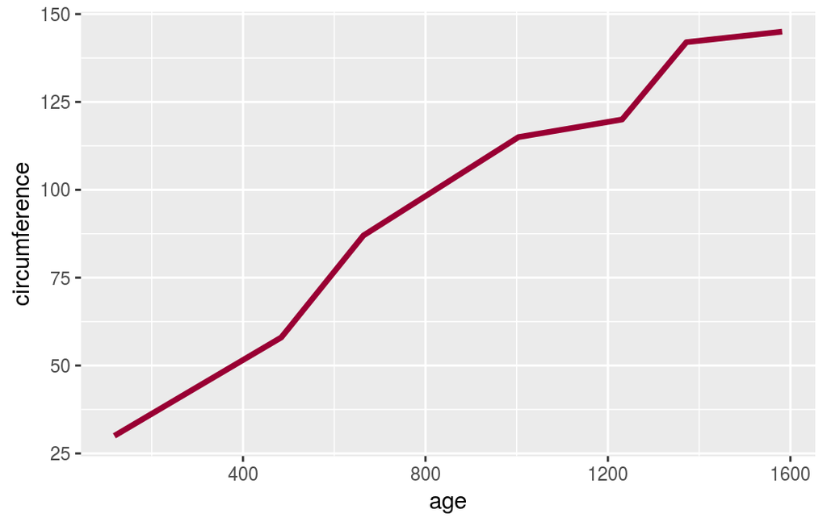

```r
require(dplyr)
# base plot of 1 tree: key components(data, aes, layer)
ggplot(data=orange %>% filter(Tree==1), mapping=aes(x=age, y=circumference)) +
  geom_line(colour= "#990033", size=1.3)
```

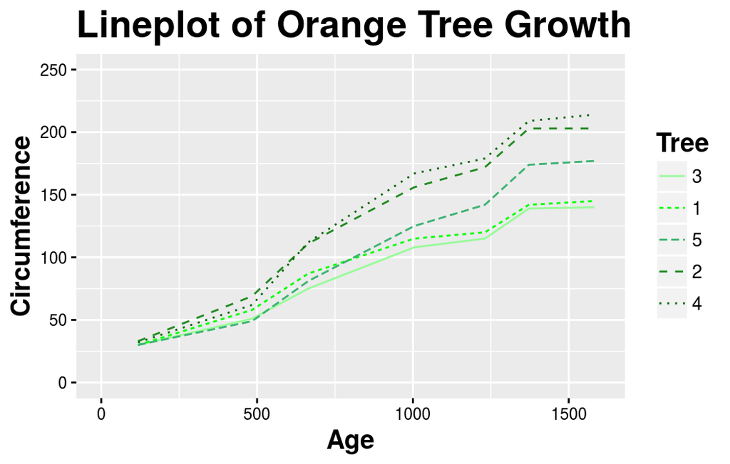

```r
# customized plot of 5 trees: key components(data, aes, layer) + scales + theme
ggplot(data=Orange, mapping=aes(x=age, y=circumference, colour=Tree)) + # Map Tree to colour scale
  geom_line(mapping=aes(linetype=Tree)) + # Map Tree to linetype scale
  scale_colour_manual(values = c("palegreen", "green", "mediumseagreen", "forestgreen" ,"darkgreen")) + # customize colours
  ylim(0,250) + xlim(0,1600) + # set axis limits
  ggtitle("Lineplot of Orange Tree Growth") + # set title
  xlab("Age") + ylab("Circumference") + # set axes titles
  theme(axis.text = element_text(colour = "black"), # customize axis text
  axis.ticks = element_line(colour = "black"), # customize axis ticks
  axis.title = element_text(colour = "black", size = 14, face = "bold"), # customize axes title
  plot.title = element_text(colour = "black", size = 20, face = "bold"), # customize plot title
  legend.text = element_text(colour="black", size=10), # customize legend text
  legend.title = element_text(colour = "black", size = 14, face = "bold")) # customize legend title
```